# Supply Chain Analytics – Demand Forecasting & Anomaly Detection

## Day 6 - Anomaly Detection.

```python
#import required libraries

import pandas as pd
import numpy as np
import matplotlib.pyplot as plt
import seaborn as sns

from scipy.stats import zscore
from sklearn.ensemble import IsolationForest

print("Libraries Imported Successfully")
```

```
Libraries Imported Successfully
```

```python
#load feature engineered dataset

file_path = r"C:\Users\LENOVO\Desktop\Supply-Chain-Demand-Forecasting-Anomaly-Detection\data\processed\supply_chain_feature_engineered.csv"

df = pd.read_csv(file_path)

print("Feature-Engineered Dataset Loaded Successfully")
print("Rows    :", df.shape[0])
print("Columns :", df.shape[1])
```

```
Feature-Engineered Dataset Loaded Successfully
Rows    : 83750
Columns : 33
```

```python
#convert date and sort data

df["Date"] = pd.to_datetime(df["Date"])

df = df.sort_values(
    ["SKU_ID", "Warehouse_ID", "Date"]
).reset_index(drop=True)

print("Date Converted and Data Sorted Successfully")
print("Date Type :", df["Date"].dtype)
print("Start Date:", df["Date"].min())
print("End Date  :", df["Date"].max())
```

```
Date Converted and Data Sorted Successfully
Date Type : datetime64[us]
Start Date: 2024-01-31 00:00:00
End Date  : 2024-12-30 00:00:00
```

```python
#verify time-series structure

print("Unique SKUs       :", df["SKU_ID"].nunique())
print("Unique Warehouses :", df["Warehouse_ID"].nunique())
print("Unique Regions    :", df["Region"].nunique())

print("\nAnomaly Analysis Variables:")
print([
    "Units_Sold",
    "Inventory_Level",
    "Order_Quantity"
])

print("\nMissing Values:")
print(
    df[
        ["Units_Sold", "Inventory_Level", "Order_Quantity"]
    ].isnull().sum()
)

print("\nDuplicate Rows:", df.duplicated().sum())
```

```
Unique SKUs       : 50
Unique Warehouses : 5
Unique Regions    : 4

Anomaly Analysis Variables:
['Units_Sold', 'Inventory_Level', 'Order_Quantity']

Missing Values:
Units_Sold         0
Inventory_Level    0
Order_Quantity     0
dtype: int64

Duplicate Rows: 0
```

```python
# define anomaly columns

anomaly_columns = [
    "Units_Sold",
    "Inventory_Level",
    "Demand_Forecast",
    "Forecast_Error"
]

print("Anomaly Detection Columns:")
for col in anomaly_columns:
    print("-", col)
```

```
Anomaly Detection Columns:
- Units_Sold
- Inventory_Level
- Demand_Forecast
- Forecast_Error
```

```python
# calculate IQR bounds

iqr_bounds = {}

for col in anomaly_columns:

    Q1 = df[col].quantile(0.25)
    Q3 = df[col].quantile(0.75)
    IQR = Q3 - Q1

    lower_bound = Q1 - 1.5 * IQR
    upper_bound = Q3 + 1.5 * IQR

    iqr_bounds[col] = {
        "Q1": Q1,
        "Q3": Q3,
        "IQR": IQR,
        "Lower_Bound": lower_bound,
        "Upper_Bound": upper_bound
    }

iqr_summary = pd.DataFrame(iqr_bounds).T

print("IQR Anomaly Detection Bounds")
display(iqr_summary.round(2))
```

```
IQR Anomaly Detection Bounds
```

|  | Q1 | Q3 | IQR | Lower_Bound | Upper_Bound |
| --- | --- | --- | --- | --- | --- |
| Units_Sold | 13.00 | 27.00 | 14.00 | -8.00 | 48.00 |
| Inventory_Level | 368.00 | 558.00 | 190.00 | 83.00 | 843.00 |
| Demand_Forecast | 12.46 | 26.95 | 14.49 | -9.27 | 48.68 |
| Forecast_Error | -2.02 | 1.99 | 4.01 | -8.04 | 8.00 |

```python
# create anomaly flags

for col in anomaly_columns:

    Q1 = df[col].quantile(0.25)
    Q3 = df[col].quantile(0.75)
    IQR = Q3 - Q1

    lower_bound = Q1 - 1.5 * IQR
    upper_bound = Q3 + 1.5 * IQR

    flag_name = f"{col}_Anomaly"

    df[flag_name] = (
        (df[col] < lower_bound) |
        (df[col] > upper_bound)
    )

print("Anomaly Flags Created Successfully")

print("\nAnomaly Counts:")
for col in anomaly_columns:
    flag_name = f"{col}_Anomaly"
    print(f"{flag_name:<30}: {df[flag_name].sum()}")
```

```
Anomaly Flags Created Successfully

Anomaly Counts:
Units_Sold_Anomaly            : 109
Inventory_Level_Anomaly       : 18
Demand_Forecast_Anomaly       : 147
Forecast_Error_Anomaly        : 608
```

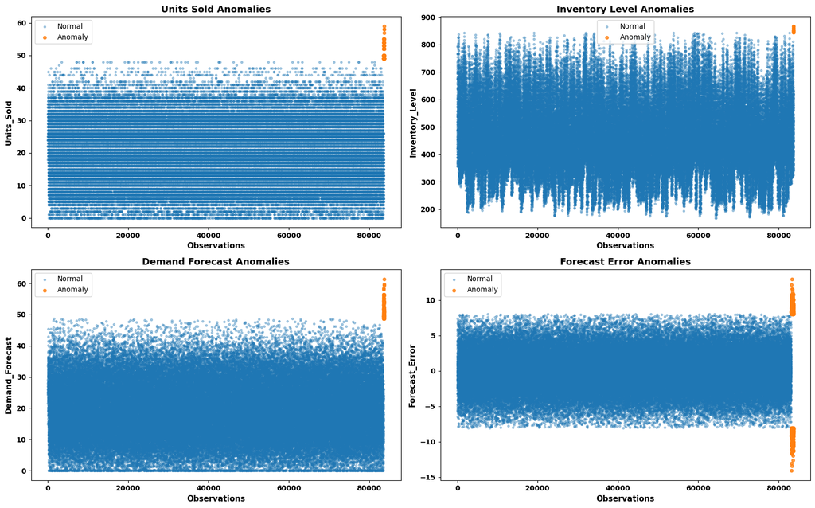

```python
# visualize anomaly distribution

fig, axes = plt.subplots(2, 2, figsize=(16, 10))

plot_columns = [
    ("Units_Sold", "Units Sold Anomalies"),
    ("Inventory_Level", "Inventory Level Anomalies"),
    ("Demand_Forecast", "Demand Forecast Anomalies"),
    ("Forecast_Error", "Forecast Error Anomalies")
]

for ax, (col, title) in zip(axes.flat, plot_columns):

    flag = f"{col}_Anomaly"

    normal_data = df.loc[~df[flag], col]
    anomaly_data = df.loc[df[flag], col]

    ax.scatter(
        range(len(normal_data)),
        normal_data,
        s=8,
        alpha=0.35,
        label="Normal"
    )

    ax.scatter(
        range(len(normal_data), len(normal_data) + len(anomaly_data)),
        anomaly_data,
        s=18,
        alpha=0.8,
        label="Anomaly"
    )

    ax.set_title(title, fontsize=13, fontweight="bold")
    ax.set_xlabel("Observations", fontsize=11, fontweight="bold")
    ax.set_ylabel(col, fontsize=11, fontweight="bold")

    ax.tick_params(axis="both", labelsize=10)

    for label in ax.get_xticklabels() + ax.get_yticklabels():
        label.set_fontweight("bold")

    ax.legend()

plt.tight_layout()
plt.show()
```

```python
# calculate z-score

from scipy.stats import zscore

zscore_columns = [
    "Units_Sold",
    "Inventory_Level",
    "Demand_Forecast",
    "Forecast_Error"
]

for col in zscore_columns:
    df[f"{col}_ZScore"] = zscore(df[col])

print("Z-Score Features Created Successfully")

display(
    df[
        zscore_columns +
        [f"{col}_ZScore" for col in zscore_columns]
    ].head(10).round(2)
)
```

```
Z-Score Features Created Successfully
```

|  | Units_Sold | Inventory_Level | Demand_Forecast | Forecast_Error | Units_Sold_ZScore | Inventory_Level_ZScore | Demand_Forecast_ZScore | Forecast_Error_ZScore |
| --- | --- | --- | --- | --- | --- | --- | --- | --- |
| 0 | 18 | 754 | 14.94 | 3.06 | -0.20 | 2.21 | -0.51 | 1.03 |
| 1 | 34 | 720 | 33.54 | 0.46 | 1.53 | 1.95 | 1.41 | 0.16 |
| 2 | 24 | 696 | 25.21 | -1.21 | 0.45 | 1.77 | 0.55 | -0.40 |
| 3 | 22 | 674 | 21.56 | 0.44 | 0.24 | 1.60 | 0.18 | 0.16 |
| 4 | 32 | 642 | 26.98 | 5.02 | 1.31 | 1.35 | 0.74 | 1.69 |
| 5 | 25 | 617 | 26.03 | -1.03 | 0.56 | 1.16 | 0.64 | -0.34 |
| 6 | 24 | 593 | 24.90 | -0.90 | 0.45 | 0.97 | 0.52 | -0.29 |
| 7 | 35 | 558 | 29.18 | 5.82 | 1.64 | 0.71 | 0.96 | 1.96 |
| 8 | 22 | 536 | 24.32 | -2.32 | 0.24 | 0.54 | 0.46 | -0.77 |
| 9 | 28 | 508 | 27.93 | 0.07 | 0.88 | 0.32 | 0.83 | 0.03 |

```python
# create z-score anomaly flags

z_threshold = 3

for col in zscore_columns:
    z_col = f"{col}_ZScore"
    flag_col = f"{col}_Z_Anomaly"

    df[flag_col] = df[z_col].abs() > z_threshold

print("Z-Score Anomaly Flags Created Successfully")

print("\nZ-Score Anomaly Counts:")

for col in zscore_columns:
    flag_col = f"{col}_Z_Anomaly"
    print(f"{flag_col:<30}: {df[flag_col].sum()}")
```

```
Z-Score Anomaly Flags Created Successfully

Z-Score Anomaly Counts:
Units_Sold_Z_Anomaly          : 160
Inventory_Level_Z_Anomaly     : 5
Demand_Forecast_Z_Anomaly     : 131
Forecast_Error_Z_Anomaly      : 226
```

```python
# compare IQR and Z-score anomalies

comparison_data = []

for col in anomaly_columns:

    iqr_flag = f"{col}_Anomaly"
    z_flag = f"{col}_Z_Anomaly"

    iqr_count = df[iqr_flag].sum()
    z_count = df[z_flag].sum()

    both_count = (df[iqr_flag] & df[z_flag]).sum()
    iqr_only = (df[iqr_flag] & ~df[z_flag]).sum()
    z_only = (~df[iqr_flag] & df[z_flag]).sum()

    comparison_data.append([
        col,
        iqr_count,
        z_count,
        both_count,
        iqr_only,
        z_only
    ])

anomaly_comparison = pd.DataFrame(
    comparison_data,
    columns=[
        "Feature",
        "IQR_Anomalies",
        "ZScore_Anomalies",
        "Detected_By_Both",
        "IQR_Only",
        "ZScore_Only"
    ]
)

print("IQR vs Z-Score Anomaly Comparison")

display(anomaly_comparison)
```

```
IQR vs Z-Score Anomaly Comparison
```

|  | Feature | IQR_Anomalies | ZScore_Anomalies | Detected_By_Both | IQR_Only | ZScore_Only |
| --- | --- | --- | --- | --- | --- | --- |
| 0 | Units_Sold | 109 | 160 | 109 | 0 | 51 |
| 1 | Inventory_Level | 18 | 5 | 5 | 13 | 0 |
| 2 | Demand_Forecast | 147 | 131 | 131 | 16 | 0 |
| 3 | Forecast_Error | 608 | 226 | 226 | 382 | 0 |

```python
# create combined anomaly score

iqr_flags = [f"{col}_Anomaly" for col in anomaly_columns]
z_flags = [f"{col}_Z_Anomaly" for col in anomaly_columns]

df["IQR_Anomaly_Count"] = df[iqr_flags].sum(axis=1)
df["ZScore_Anomaly_Count"] = df[z_flags].sum(axis=1)

df["Combined_Anomaly_Score"] = (
    df["IQR_Anomaly_Count"] +
    df["ZScore_Anomaly_Count"]
)

df["Confirmed_Anomaly"] = df["Combined_Anomaly_Score"] >= 2

print("Combined Anomaly Detection Completed")

print("\nCombined Anomaly Score Distribution:")
display(
    df["Combined_Anomaly_Score"]
    .value_counts()
    .sort_index()
)

print(
    "\nConfirmed Anomalies :",
    df["Confirmed_Anomaly"].sum()
)

print(
    "Normal Observations :",
    (~df["Confirmed_Anomaly"]).sum()
)
```

```
Combined Anomaly Detection Completed

Combined Anomaly Score Distribution:
```

```
Combined_Anomaly_Score
0    82924
1      430
2      295
3       21
4       79
5        1
Name: count, dtype: int64
```

```
Confirmed Anomalies : 396
Normal Observations : 83354
```

```python
# summarize confirmed anomalies

confirmed_anomalies = df[df["Confirmed_Anomaly"]].copy()

print("Confirmed Anomaly Dataset")
print("Rows :", len(confirmed_anomalies))
print("Columns :", len(confirmed_anomalies.columns))

display(
    confirmed_anomalies[
        [
            "Date",
            "SKU_ID",
            "Warehouse_ID",
            "Supplier_ID",
            "Region",
            "Units_Sold",
            "Inventory_Level",
            "Demand_Forecast",
            "Forecast_Error",
            "Combined_Anomaly_Score"
        ]
    ].head(10)
)
```

```
Confirmed Anomaly Dataset
Rows : 396
Columns : 49
```

|  | Date | SKU_ID | Warehouse_ID | Supplier_ID | Region | Units_Sold | Inventory_Level | Demand_Forecast | Forecast_Error | Combined_Anomaly_Score |
| --- | --- | --- | --- | --- | --- | --- | --- | --- | --- | --- |
| 24 | 2024-02-24 | SKU_1 | WH_1 | SUP_8 | South | 31 | 455 | 40.18 | -9.18 | 2 |
| 68 | 2024-04-08 | SKU_1 | WH_1 | SUP_8 | North | 50 | 490 | 53.20 | -3.20 | 4 |
| 71 | 2024-04-11 | SKU_1 | WH_1 | SUP_8 | East | 49 | 374 | 50.21 | -1.21 | 4 |
| 374 | 2024-03-10 | SKU_1 | WH_2 | SUP_5 | South | 52 | 509 | 50.18 | 1.82 | 4 |
| 915 | 2024-10-02 | SKU_1 | WH_3 | SUP_9 | North | 9 | 368 | 0.00 | 9.00 | 2 |
| 955 | 2024-11-11 | SKU_1 | WH_3 | SUP_9 | South | 13 | 349 | 2.98 | 10.02 | 2 |
| 1064 | 2024-03-30 | SKU_1 | WH_4 | SUP_2 | East | 42 | 545 | 49.51 | -7.51 | 2 |
| 1396 | 2024-03-27 | SKU_1 | WH_5 | SUP_5 | South | 33 | 391 | 42.34 | -9.34 | 2 |
| 1430 | 2024-04-30 | SKU_1 | WH_5 | SUP_5 | North | 49 | 402 | 48.63 | 0.37 | 2 |
| 1509 | 2024-07-18 | SKU_1 | WH_5 | SUP_5 | West | 20 | 509 | 9.25 | 10.75 | 2 |

```python
# anomaly distribution by SKU

sku_anomalies = (
    confirmed_anomalies
    .groupby("SKU_ID")
    .size()
    .sort_values(ascending=False)
)

print("Confirmed Anomalies by SKU")

display(
    sku_anomalies
    .head(10)
    .to_frame("Anomaly_Count")
)
```

```
Confirmed Anomalies by SKU
```

| SKU_ID | Anomaly_Count |
| --- | --- |
| SKU_29 | 17 |
| SKU_34 | 14 |
| SKU_32 | 13 |
| SKU_26 | 12 |
| SKU_38 | 12 |
| SKU_36 | 11 |
| SKU_4 | 11 |
| SKU_33 | 11 |
| SKU_10 | 11 |
| SKU_2 | 11 |

```python
# anomaly distribution by warehouse

warehouse_anomalies = (
    confirmed_anomalies
    .groupby("Warehouse_ID")
    .size()
    .sort_values(ascending=False)
)

print("Confirmed Anomalies by Warehouse")

display(
    warehouse_anomalies
    .to_frame("Anomaly_Count")
)
```

```
Confirmed Anomalies by Warehouse
```

| Warehouse_ID | Anomaly_Count |
| --- | --- |
| WH_2 | 92 |
| WH_1 | 81 |
| WH_5 | 81 |
| WH_3 | 72 |
| WH_4 | 70 |

```python
# anomaly distribution by region

region_anomalies = (
    confirmed_anomalies
    .groupby("Region")
    .size()
    .sort_values(ascending=False)
)

print("Confirmed Anomalies by Region")

display(
    region_anomalies
    .to_frame("Anomaly_Count")
)
```

```
Confirmed Anomalies by Region
```

| Region | Anomaly_Count |
| --- | --- |
| North | 104 |
| East | 100 |
| South | 96 |
| West | 96 |

```python
# Date-wise anomaly frequency
# date-wise anomaly analysis

daily_anomalies = (
    confirmed_anomalies.groupby("Date")
    .size()
    .reset_index(name="Anomaly_Count")
)

print("Date-wise Anomaly Summary:")
print(daily_anomalies.head())

print("\nHighest Anomaly Dates:")
print(
    daily_anomalies
    .sort_values("Anomaly_Count", ascending=False)
    .head(10)
)
```

```
Date-wise Anomaly Summary:
        Date  Anomaly_Count
0 2024-02-01              2
1 2024-02-03              1
2 2024-02-04              1
3 2024-02-05              4
4 2024-02-06              1

Highest Anomaly Dates:
         Date  Anomaly_Count
48 2024-03-25              7
38 2024-03-15              6
50 2024-03-27              5
46 2024-03-23              5
47 2024-03-24              5
42 2024-03-19              5
35 2024-03-12              5
44 2024-03-21              5
82 2024-04-30              5
51 2024-03-28              5
```

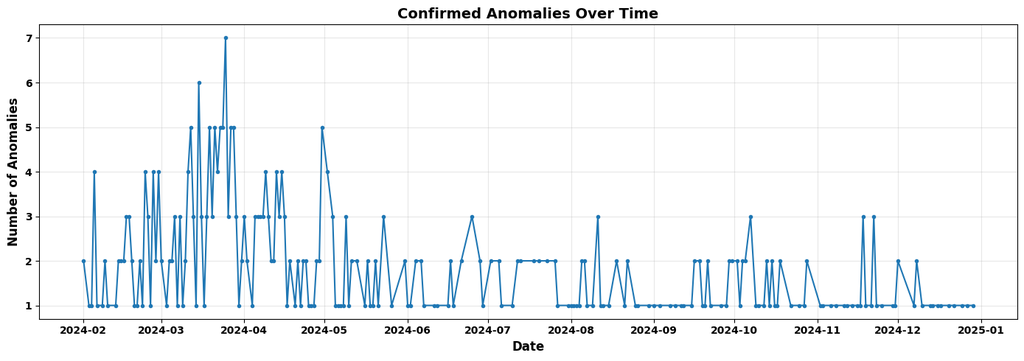

```python
# Date-wise anomaly visualization
# visualize anomaly frequency over time

plt.figure(figsize=(14, 5))

plt.plot(
    daily_anomalies["Date"],
    daily_anomalies["Anomaly_Count"],
    marker="o",
    markersize=3,
    linewidth=1.5
)

plt.title("Confirmed Anomalies Over Time", fontsize=14, fontweight="bold")
plt.xlabel("Date", fontsize=12, fontweight="bold", color="black")
plt.ylabel("Number of Anomalies", fontsize=12, fontweight="bold", color="black")

plt.xticks(fontweight="bold", color="black")
plt.yticks(fontweight="bold", color="black")

plt.grid(alpha=0.3)
plt.tight_layout()
plt.show()
```

```
Confirmed Anomaly Score Distribution:
Combined_Anomaly_Score
2    295
3     21
4     79
5      1
Name: count, dtype: int64
```

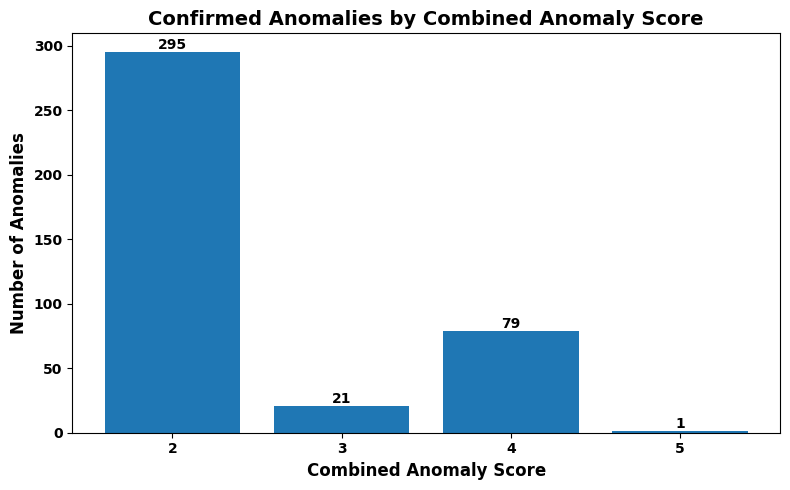

```python
# Anomaly score distribution
# anomaly score analysis

score_distribution = (
    confirmed_anomalies["Combined_Anomaly_Score"]
    .value_counts()
    .sort_index()
)

print("Confirmed Anomaly Score Distribution:")
print(score_distribution)

plt.figure(figsize=(8, 5))

bars = plt.bar(
    score_distribution.index.astype(str),
    score_distribution.values
)

plt.title("Confirmed Anomalies by Combined Anomaly Score",
          fontsize=14, fontweight="bold")

plt.xlabel("Combined Anomaly Score",
           fontsize=12, fontweight="bold", color="black")

plt.ylabel("Number of Anomalies",
           fontsize=12, fontweight="bold", color="black")

plt.xticks(fontweight="bold", color="black")
plt.yticks(fontweight="bold", color="black")

for bar, value in zip(bars, score_distribution.values):
    plt.text(
        bar.get_x() + bar.get_width() / 2,
        bar.get_height(),
        str(value),
        ha="center",
        va="bottom",
        fontweight="bold"
    )

plt.tight_layout()
plt.show()
```

```
Anomaly Driver Counts:
Forecast Error     229
Demand Forecast    137
Units Sold         109
Inventory Level      6
dtype: int64
```

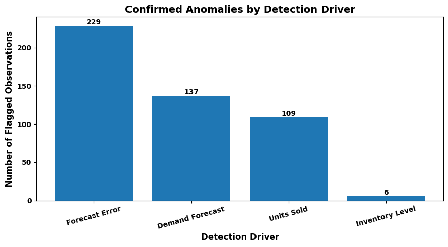

```python
# Which factor is driving anomalies?
# anomaly driver analysis

anomaly_driver_counts = {
    "Units Sold": confirmed_anomalies["Units_Sold_Anomaly"].sum(),
    "Inventory Level": confirmed_anomalies["Inventory_Level_Anomaly"].sum(),
    "Demand Forecast": confirmed_anomalies["Demand_Forecast_Anomaly"].sum(),
    "Forecast Error": confirmed_anomalies["Forecast_Error_Anomaly"].sum()
}

anomaly_driver = pd.Series(anomaly_driver_counts).sort_values(ascending=False)

print("Anomaly Driver Counts:")
print(anomaly_driver)

plt.figure(figsize=(9, 5))

bars = plt.bar(
    anomaly_driver.index,
    anomaly_driver.values
)

plt.title("Confirmed Anomalies by Detection Driver",
          fontsize=14, fontweight="bold")

plt.xlabel("Detection Driver",
           fontsize=12, fontweight="bold", color="black")

plt.ylabel("Number of Flagged Observations",
           fontsize=12, fontweight="bold", color="black")

plt.xticks(rotation=15, fontweight="bold", color="black")
plt.yticks(fontweight="bold", color="black")

for bar, value in zip(bars, anomaly_driver.values):
    plt.text(
        bar.get_x() + bar.get_width() / 2,
        bar.get_height(),
        str(value),
        ha="center",
        va="bottom",
        fontweight="bold"
    )

plt.tight_layout()
plt.show()
```

```python
# save confirmed anomalies

output_path = r"C:\Users\LENOVO\Desktop\Supply-Chain-Demand-Forecasting-Anomaly-Detection\data\processed\supply_chain_confirmed_anomalies.csv"

confirmed_anomalies.to_csv(
    output_path,
    index=False
)

print("Confirmed Anomaly Dataset Saved Successfully")
print("\nSaved Path:")
print(output_path)

print("\nFinal Shape:")
print(confirmed_anomalies.shape)
```

```
Confirmed Anomaly Dataset Saved Successfully

Saved Path:
C:\Users\LENOVO\Desktop\Supply-Chain-Demand-Forecasting-Anomaly-Detection\data\processed\supply_chain_confirmed_anomalies.csv

Final Shape:
(396, 49)
```

```python
# verify saved anomaly dataset

print("Final Anomaly Dataset")
print("Rows :", len(confirmed_anomalies))
print("Columns :", len(confirmed_anomalies.columns))

print("\nMissing Values :",
      confirmed_anomalies.isnull().sum().sum())

print("Duplicate Rows :",
      confirmed_anomalies.duplicated().sum())
```

```
Final Anomaly Dataset
Rows : 396
Columns : 49

Missing Values : 0
Duplicate Rows : 0
```

## Anomaly Detection – Business Interpretation

The anomaly detection analysis identified **396 confirmed anomalies** from the feature-engineered supply chain dataset using a combination of **IQR and Z-Score statistical methods**.

### Key Findings

- **Forecast Error** was the leading anomaly driver with 229 flagged observations, indicating significant gaps between actual demand and forecasted demand.
- **Demand Forecast** contributed 137 anomaly signals, highlighting unusual forecast behavior.
- **Units Sold** contributed 109 anomaly signals, indicating unusual demand patterns.
- **Inventory Level** contributed 6 anomaly signals, showing relatively fewer extreme inventory observations.

### Anomaly Severity

The combined anomaly score identified:

- 295 observations with Score 2
- 21 observations with Score 3
- 79 observations with Score 4
- 1 observation with Score 5

Higher scores indicate stronger anomaly evidence across multiple detection criteria.

### Operational Insights

- **SKU_29** recorded the highest number of confirmed anomalies with 17 cases.
- **WH_2** recorded the highest warehouse-level anomaly count with 92 cases.
- **North** recorded the highest regional anomaly count with 104 cases.
- **2024-03-25** recorded the highest daily anomaly count with 7 cases.

### Business Relevance

These anomalies can help supply chain teams identify unusual demand patterns, forecast inaccuracies, inventory irregularities, and locations requiring further investigation. The detected anomalies should be treated as **investigation alerts rather than automatically removed records**, because genuine business events can also appear as statistical anomalies.